# Aplicações

Fundamentos de Modelagem de Distribuição de Espécies no R - PPGBV 2021

Luíz Fernando Esser

05/07/2021

## Introdução

### Revisão da última aula

1. Selecionando quais modelos projetar;
2. Projetar modelos selecionados;
3. Montando um ensemble.  
   E lembre-se: Garbage in, garbage out.  
   E mais: dados de presença/ausência refletem uma condição ambiental e não geográfica.

### Na aula de hoje

1. Algebra de rasters;
2. Correlação entre rasters;
3. Refúgios;
4. Cálculo de área;
5. Limitação de dispersão;
6. Áreas protegidas e remanescentes.

## Exercício da aula passada

Enunciado: Tendo em mente o último bloco de código deste roteiro, alterne os tipos de métodos que existem para gerar um ensemble. Você percebe alguma mudança nos resultados? Quais deles é mais apropriado? Existe algum mais apropriado? Uma sugestão de resolução:

```r
library(sdm)
library(raster)
library(rgeos)
library(adehabitatHR)
```

Importar dados da ambientais e da espécie:

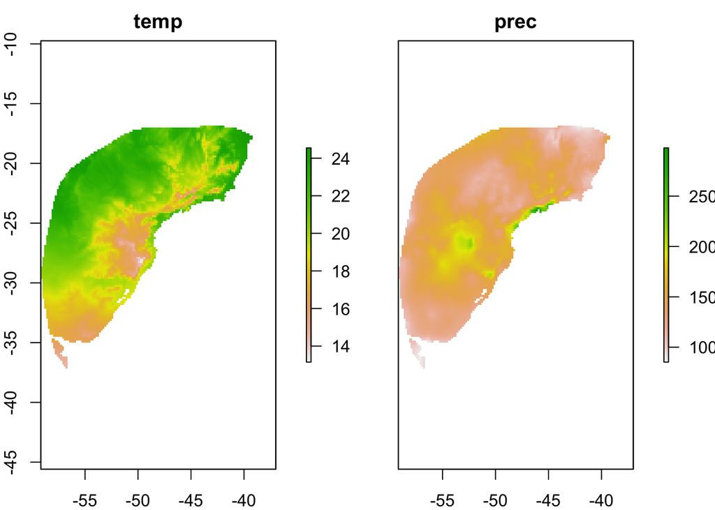

```r
df <- read.csv("spp_data/Ficus.csv")
df2 <- df[,-c(1:2)]
coordinates(df2) <- 2:3
s <- stack("current.tif")
names(s) <- c("temp", "prec")
plot(s)
```

Criar função de pré-processamento usando a função de pseudoausências da última aula:

```r
pseudoabsences <- function(sp, env){
  require(sdm)
  require(raster)
  print(paste0("Building SRE..."))
  d <- sdmData(reformulate(termlabels = names(env), response = names(sp)),
               train = sp,
               predictors = env)
  m <- sdm(~.,
           data = d,
           method='bioclim')
  p <- predict(m, env)
  p[p[]>0] <- NA
  print(paste0("Masking environment..."))
  env2 <- mask(env, p)
  print(paste0("Obtaining pseudoabsences..."))
  pa <- sampleRandom(env2, nrow(sp), sp = TRUE, na.rm=T)
  pa2 <- as.data.frame(pa)
  pa2 <- pa2[,c("x","y",names(env))]
  colnames(pa2) <- c(colnames(sp@coords),names(env))
  return(pa2)
}
pa <- pseudoabsences(df2, s)
```

```
## [1] "Building SRE..."
## [1] "Masking environment..."
## [1] "Obtaining pseudoabsences..."
```

```r
d <- sdmData(species ~ temp + prec,
             train = df2,
             predictors = s,
             bg = pa)
m <- sdm(~.,
         data=d,
         methods = c("mlp", "fda"),
         replication = "cv",
         cv.folds = 4,
         n = 2)
```

Criar ensembles com diferentes métodos:

```r
e1 <- ensemble(m,
               newdata=s,
               setting = list(method = "unweighted"))
plot(e1)
```

[output not shown]

[output not shown]

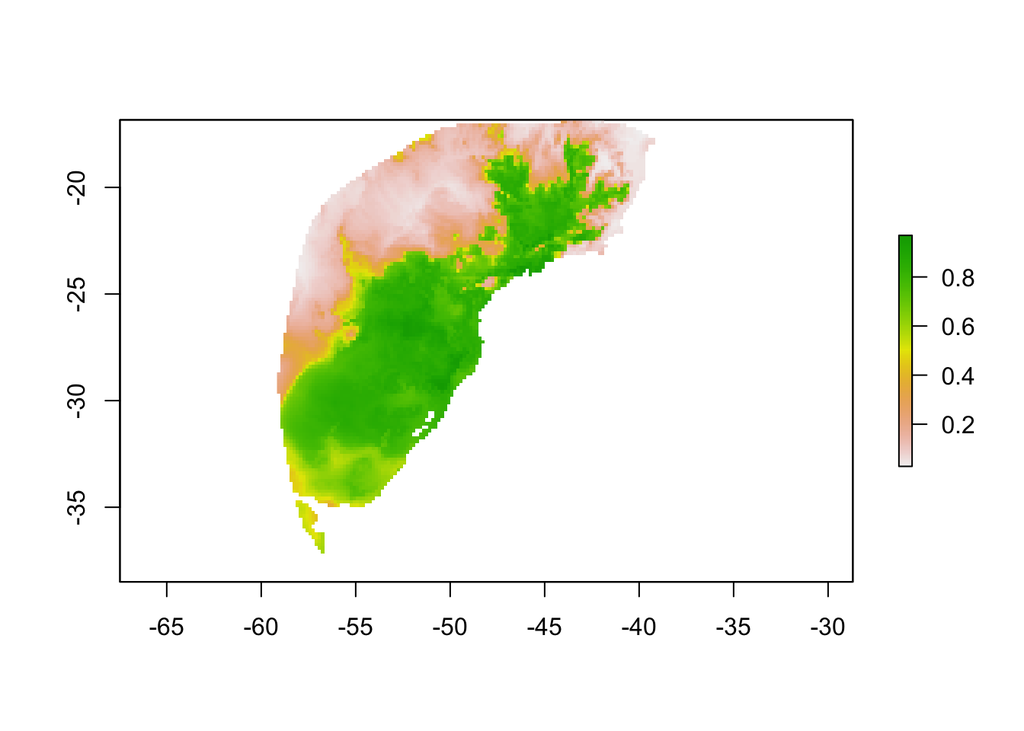

```r
e2 <- ensemble(m,
               newdata=s,
               setting = list(method = "median"))
plot(e2)
```

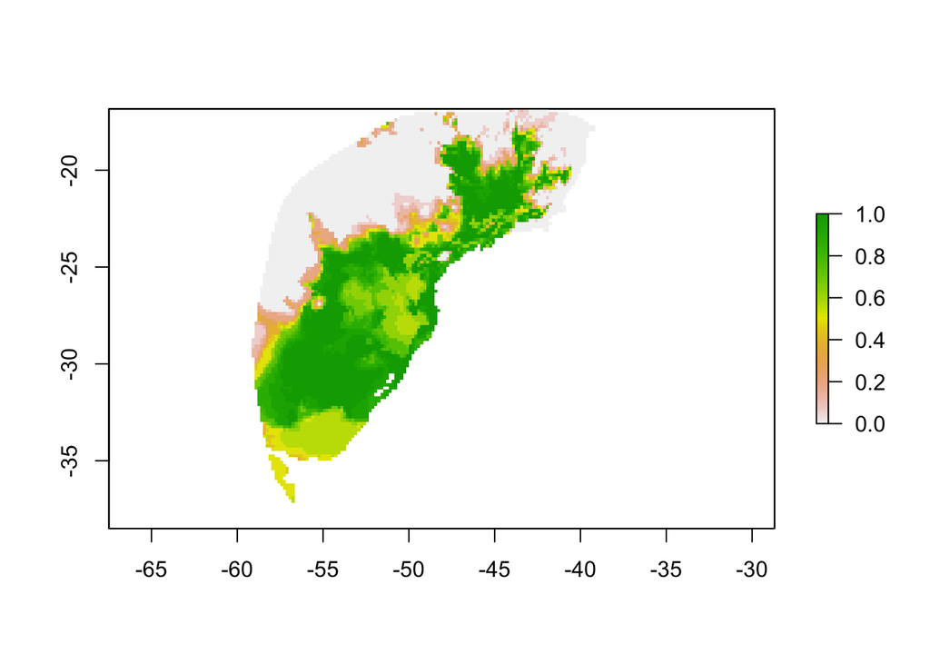

```r
e3 <- ensemble(m,
               newdata=s,
               setting = list(method = "pa"))
plot(e3)
```

```r
e4 <- ensemble(m,
               newdata=s,
               setting = list(method = "mean-unweighted"))
plot(e4)
```

[output not shown]

[output not shown]

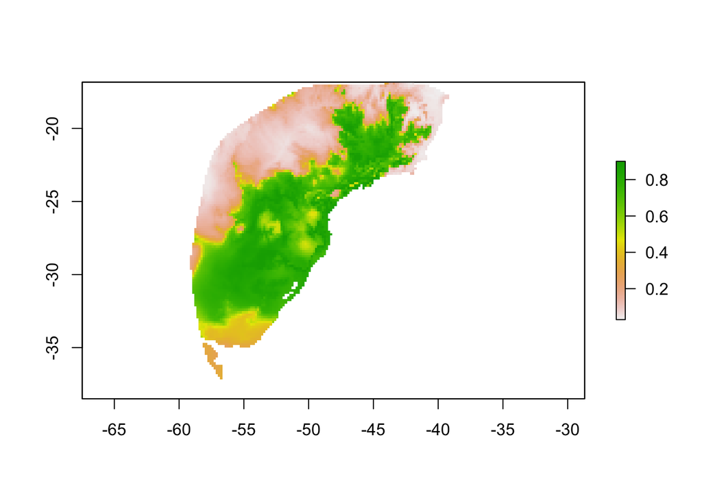

```r
e5 <- ensemble(m,
               newdata=s,
               setting = list(method = "median-unweighted"))
plot(e5)
```

Olhando os ensembles, podemos perceber que existe pouca diferença entre eles, sendo que seus resutados variam mais em interpretação do que em distribuição.

## Algebra de Rasters

Nessa etapa, aonde já temos nossos ensembles gerados, precisamos trabalhar com os rasters gerados pra atingir nossos objetivos. No R, podemos utilizar tanto os sinais matemáticos que já vimos lá na primeira aula, quanto usar funções mais amplas. Veremos primeiro os sinais matemáticos. Observe como os valores máximos e mínimos mudam a cada cálculo realizado:

```r
e<-e1
e
```

```
## class      : RasterLayer
## dimensions : 130, 133, 17290  (nrow, ncol, ncell)
## resolution : 0.1666667, 0.1666667  (x, y)
## extent     : -59.16667, -37, -38.5, -16.83333  (xmin, xmax, ymin, ymax)
## crs        : +proj=longlat +datum=WGS84 +no_defs
## source     : sdm_ensemble_w9sd4m.grd
## names      : layer
## values     : 0.0316554, 0.8738203  (min, max)
```

```r
e+e
```

```
## class      : RasterLayer
## dimensions : 130, 133, 17290  (nrow, ncol, ncell)
## resolution : 0.1666667, 0.1666667  (x, y)
## extent     : -59.16667, -37, -38.5, -16.83333  (xmin, xmax, ymin, ymax)
## crs        : +proj=longlat +datum=WGS84 +no_defs
## source     : memory
## names      : layer
## values     : 0.06331081, 1.747641  (min, max)
```

```r
e*10
```

```
## class      : RasterLayer
## dimensions : 130, 133, 17290  (nrow, ncol, ncell)
## resolution : 0.1666667, 0.1666667  (x, y)
## extent     : -59.16667, -37, -38.5, -16.83333  (xmin, xmax, ymin, ymax)
## crs        : +proj=longlat +datum=WGS84 +no_defs
## source     : memory
## names      : layer
## values     : 0.316554, 8.738204  (min, max)
```

```r
e-1
```

```
## class      : RasterLayer
## dimensions : 130, 133, 17290  (nrow, ncol, ncell)
## resolution : 0.1666667, 0.1666667  (x, y)
## extent     : -59.16667, -37, -38.5, -16.83333  (xmin, xmax, ymin, ymax)
## crs        : +proj=longlat +datum=WGS84 +no_defs
## source     : memory
## names      : layer
## values     : -0.9683446, -0.1261796  (min, max)
```

```r
e/10
```

```
## class      : RasterLayer
## dimensions : 130, 133, 17290  (nrow, ncol, ncell)
## resolution : 0.1666667, 0.1666667  (x, y)
## extent     : -59.16667, -37, -38.5, -16.83333  (xmin, xmax, ymin, ymax)
## crs        : +proj=longlat +datum=WGS84 +no_defs
## source     : memory
## names      : layer
## values     : 0.00316554, 0.08738204  (min, max)
```

As funções que podem ser utilizadas em rasters, geralmente sintetizam todos os valores das células.

```r
freq(e) # frequencia dos valores
```

```
##      value count
## [1,]     0  3379
## [2,]     1  3746
## [3,]    NA 10165
```

```r
quantile(e, probs=0.99, na.rm=T) # calculo do quantil 99.
```

```
##       99%
## 0.8645456
```

Mas as três principais funções utilizada para obter um espectro mais amplo de informações dos rasteres são as funções `cellStats` e `layerStats` do pacote raster e `calc`. A primeira, calcula informações internas aos rasters, considerando todos os valores dentro dele. A segunda e a terceira, comparam os valores entre diferentes rasters, isto é, compara-se o valor da célula 1 do raster A com o valor da célula 1 do raster B; célula 2 com célula 2, 3 com 3 e assim por diante.

```r
cellStats(e, sum) # somar todas as células de um raster
```

```
## [1] 3439.117
```

```r
cellStats(e, sd, na.rm=T) # calcular o desvio padrão dos valores de um raster, desconsiderando o desvio padrão
```

```
## [1] 0.2996407
```

```r
stk <- stack(e1,e2, e3, e4, e5)
layerStats(stack(e1,e2, e3, e4, e5), stat='cov', na.rm=T) #calcular a covariância entre os rasters
```

```
## $covariance
##            layer.1    layer.2   layer.3    layer.4    layer.5
## layer.1 0.08978457 0.09244018 0.1216975 0.08978457 0.09049281
## layer.2 0.09244018 0.10024410 0.1253821 0.09244018 0.09222407
## layer.3 0.12169747 0.12538214 0.1733549 0.12169747 0.12242273
## layer.4 0.08978457 0.09244018 0.1216975 0.08978457 0.09049281
## layer.5 0.09049281 0.09222407 0.1224227 0.09049281 0.09166154
##
## $mean
##   layer.1   layer.2   layer.3   layer.4   layer.5
## 0.4826830 0.4996908 0.4900088 0.4826830 0.4796676
```

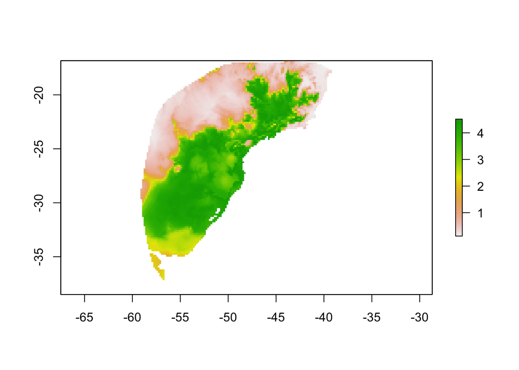

```r
soma <- calc(stk, sum) # soma os rasters em um só
plot(soma)
```

Essas funções são cruciais para as próximas ferramentas.

## Correlação entre rasters

A primeira e mais intuitiva a partir daqui é o cálculo da correlação entre rasters. Usando a função `layerStats` podemos indicar:

```r
layerStats(stack(e1,e2, e3, e4, e5), stat='pearson', na.rm=T)
```

```
## $`pearson correlation coefficient`
##           layer.1   layer.2   layer.3   layer.4   layer.5
## layer.1 1.0000000 0.9743848 0.9754672 1.0000000 0.9975155
## layer.2 0.9743848 1.0000000 0.9511264 0.9743848 0.9621024
## layer.3 0.9754672 0.9511264 1.0000000 0.9754672 0.9711816
## layer.4 1.0000000 0.9743848 0.9754672 1.0000000 0.9975155
## layer.5 0.9975155 0.9621024 0.9711816 0.9975155 1.0000000
##
## $mean
##   layer.1   layer.2   layer.3   layer.4   layer.5
## 0.4826830 0.4996908 0.4900088 0.4826830 0.4796676
```

A partir desta função podemos comparar rasters de forma numérica, sendo que este resultado nos mostra como os diferentes tipos de ensemble são parecidos entre si.